# DS Capstone Week 2 Report

L Colucci

June 24, 2018

## Executive Summary

To begin with, one must identify a basic approach to the predictive model. At this point I am not sure if we will be given guidance around the ulitmate outcome, or if we decide on our own. The specific question I’m concerned about is what we are predicting - given one word, pick the next, or given a few letters, or multiple words.

This is important to know at this stage, because often in working with text mining, we remove stop words. From my initial anaylsis, these words (“the”,“to”,“and”,“a”, etc) are the most common, and a decision should be made as to removing or not.

If we are interested in doing a predictive model, we would want to include them, as they are most common and when typing, so they would likely be included in searches. At this point, I will be including the stop words.

## Approach

I’ve started working with the tidytext package; it appears to be well suited for simple tokenization. My inital thought was to identify all of the words in the three files; find a percentage (40-50%?) of the most common, and then do a second pass through the data to find the most common words that follow each of the top words. This may be time intensive with regular expressions, and there may be better ways to do this with existing packages.

At this point, I have not learned enough about tidytext to know the best approach. To start with, I have tokenized the three data sets, and done word counts, and observation of the most and least common words.

## Data analysis

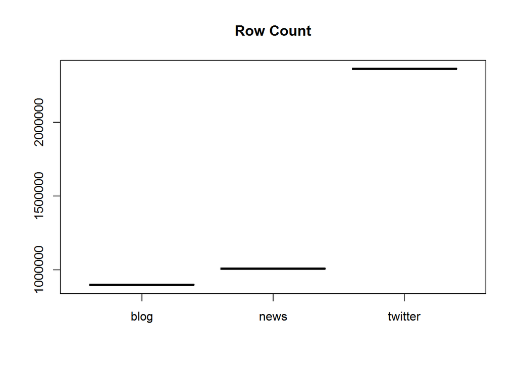

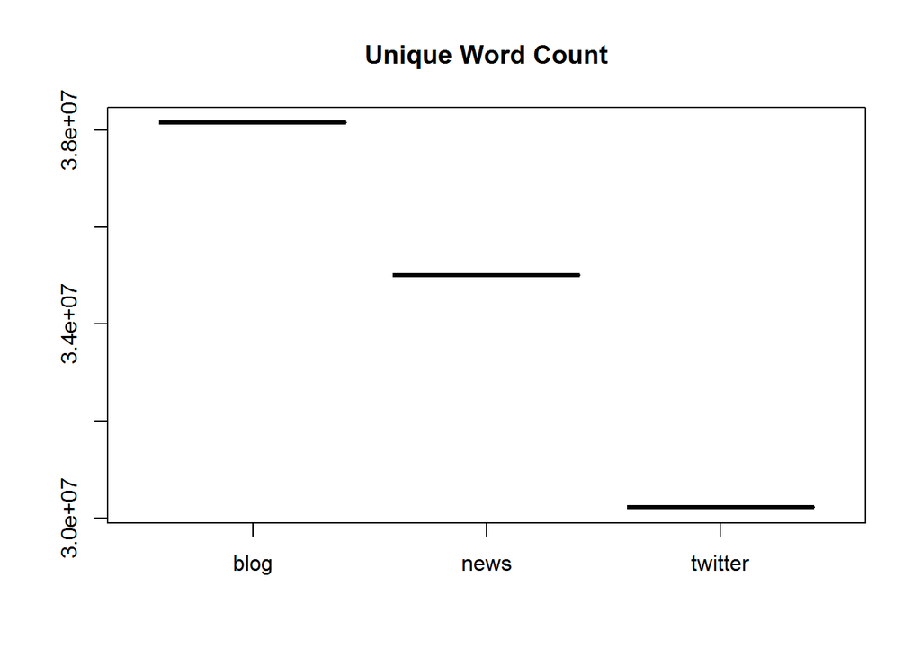

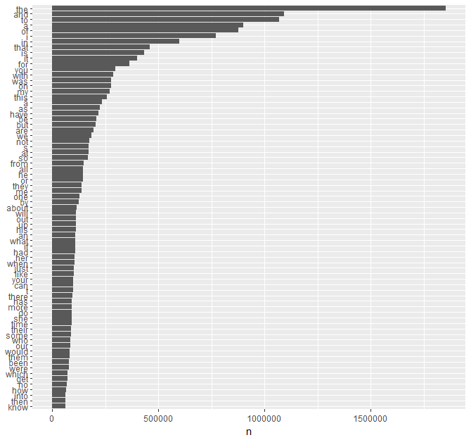

Top Words - Blog 60k+

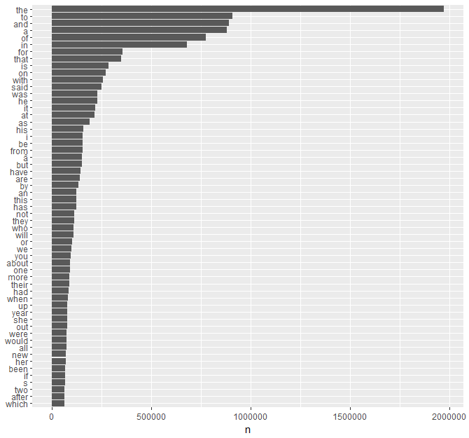

Top Words - News 60k+

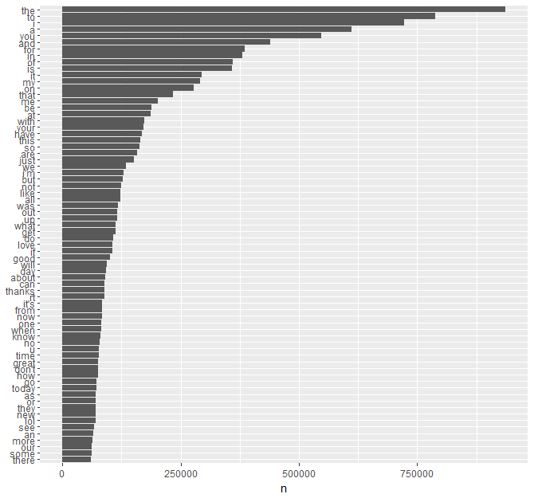

Top Words - Twitter 60k+

In all of the three files, the top words (60k appearances or more), appear to be very similar. Knowing that “the” will appear over 1.5 million times lets us know that we will have a lot of matches if that is the word we’re trying to predict. It may not be feasible to attempt to match that. In our design, we may consider matching only after some of the most common words; when we’re considering what to match, perhaps in those cases we’d ignore “the” in the initial count (ie, if we were planning to match after the 2nd word, when the first word was “the”, we would match after the third word).

## Bigrams

We will need to do some experimentation with Shiny, at the correct time, to determine what is an appropriate set size to work with (1-2 million?). We will have to choose to ignore most of the very uncommon words/pairings, in favor of the most common for the most common words.